# BBVA Success - Definitions of Success

Magdalena Bennett[^1]

William Fuchs[^2]

Jaime Millán[^3]

October 3rd, 2024

## Edits

- **09/17/24**:
  - Changed *q634* and *q635* for the ratio, and took out the original variables (including a missing dummy).
  - Took out “Business situation” from predicting models.
  - Tested taking out “cluster” variable for entire sample prediction/ taking out definition of success variables.
  - Added a love plot beside varImp plots.
- **09/18/24**:
  - Changed max and min income to a ratio with respect to assets in their first loan.
  - Fix 5 obs that had missing ratio (both *q634* and *q635* were 0).
  - Added preliminary code for selecting 10 variables.
- **09/26/24**:
  - Imputed missing survey age (148) with admin data
  - Changed max and min income to logarithms (to treat outliers) and avoid high means for standardization.
  - Checked ratio of resources needed and increase of income (transformed to logs)
- **10/03/24**:
  - Changed max and min income to percentile (1-100).
  - Changed ratio of investment and income growth to percentile (1-100).
  - Included `cluster` variable in the model selection.

# Definition of Success

In this section, we analyze the characteristics of clients according to their definition of success. We will use the following questions to build definitions of success in a data-driven way:

1. Why do you consider yourself a successful person? (Open)
2. For you, a successful person is mainly someone who:
- Is recognized by the community.
- Has stability at home.
- Has stability in their business.
3. For you, a successful business is if:
- It has managed to grow.
- It has manages to maintain itself.
- It has generated employment.
- It has generated a positive change in the community.
- It allows me to cover household necessities.
4. Imagine that everything goes well, what would be the size of your business in 5 years?
- Smaller/the same as now.
- Larger than now.
- Much larger than now.
5. Imagine that everything goes well, how many people would work in your business in 5 years? (% growth)
6. If the opportunity presented itself to work in a company with a permanent company, what would you do?
- Sell my current business/ Close my current business if I can’t sell it.
- Keep my current business (in parallel or managed by another person).
- Wouldn’t accept it.
7. What amount of money would you accept for a job? (1,000 US$)
8. You would like that your children:
- Were entrepreneurs and had their own business.
- Managed the family business.
- Had a secure job.

## Defining Success

Using the previous questions, we perform a hierarchical clustering analysis (HCA) to obtain optimal clusters based on the customers’ responses. Based on the responses, we create two different clusters to assess differences in definitions of success. To increase the disparity between both groups, we exclude observations that are in the 10% closer to the other cluster’s center, dropping 184 out of 1833 total observations.

The following table shows the comparison between both clusters in terms of the previous data:

Table 1. Balance table across clients’ responses according to clusters

|  | Cluster 1 (N=1188) Mean | Cluster 1 (N=1188) Std. Dev. | Cluster 2 (N=461) Mean | Cluster 2 (N=461) Std. Dev. | Diff. in Means | p |
| --- | --- | --- | --- | --- | --- | --- |
| What makes you successful? - business | 0.121 | 0.327 | 0.158 | 0.365 | 0.037 | 0.057 |
| What makes you successful? - family | 0.024 | 0.152 | 0.000 | 0.000 | -0.024 | 0.000 |
| A successful person: Is recognized by the community | 0.200 | 0.400 | 0.007 | 0.080 | -0.194 | 0.000 |
| A successful person: Has stability in her home | 0.383 | 0.486 | 0.449 | 0.498 | 0.066 | 0.015 |
| A successful person: Has stability in her business | 0.417 | 0.493 | 0.544 | 0.499 | 0.128 | 0.000 |
| A successful business: Has managed to grow | 0.355 | 0.479 | 0.360 | 0.481 | 0.005 | 0.853 |
| A successful business: Has managed to sustain | 0.216 | 0.412 | 0.260 | 0.439 | 0.044 | 0.064 |
| A successful business: Has generated employment | 0.136 | 0.343 | 0.174 | 0.379 | 0.037 | 0.067 |
| A successful business: Has brought about a positive change in the community | 0.102 | 0.303 | 0.000 | 0.000 | -0.102 | 0.000 |
| A successful business: Covers the household needs | 0.190 | 0.393 | 0.206 | 0.405 | 0.016 | 0.472 |
| Business would be much larger | 0.608 | 0.488 | 0.577 | 0.495 | -0.031 | 0.256 |
| Business would be larger | 0.000 | 0.000 | 0.000 | 0.000 | 0.000 |  |
| Business would be equal/smaller | 0.392 | 0.488 | 0.423 | 0.495 | 0.031 | 0.256 |
| How many workers would you have? (prop. over current workers) | 3.421 | 3.515 | 3.579 | 4.152 | 0.157 | 0.472 |
| If offered a job: Accept and keep | 0.788 | 0.409 | 0.061 | 0.239 | -0.727 | 0.000 |
| If offered a job: Close or sell | 0.000 | 0.000 | 0.000 | 0.000 | 0.000 |  |
| If offered a job: Not accept | 0.212 | 0.409 | 0.939 | 0.239 | 0.727 | 0.000 |
| What amount of money would a job have to pay? (1,000 US$) | 5.187 | 5.439 | 11.976 | 0.535 | 6.789 | 0.000 |
| What amount of money would a job have to pay? (No amount) | 0.385 | 0.487 | 0.998 | 0.047 | 0.613 | 0.000 |
| You would like your children: Were entrepreneurs and had their own business | 0.573 | 0.495 | 0.644 | 0.479 | 0.071 | 0.008 |
| You would like your children: Took charge of the family business (their business) | 0.238 | 0.426 | 0.356 | 0.479 | 0.118 | 0.000 |
| You would like your children: Had a secure job | 0.189 | 0.391 | 0.000 | 0.000 | -0.189 | 0.000 |

The following plot shows the relative importance of the previous variables in terms of the difference between clusters measured in standard deviations. Negative differences imply a higher value for cluster 2 and positive differences imply a higher value for cluster 1.

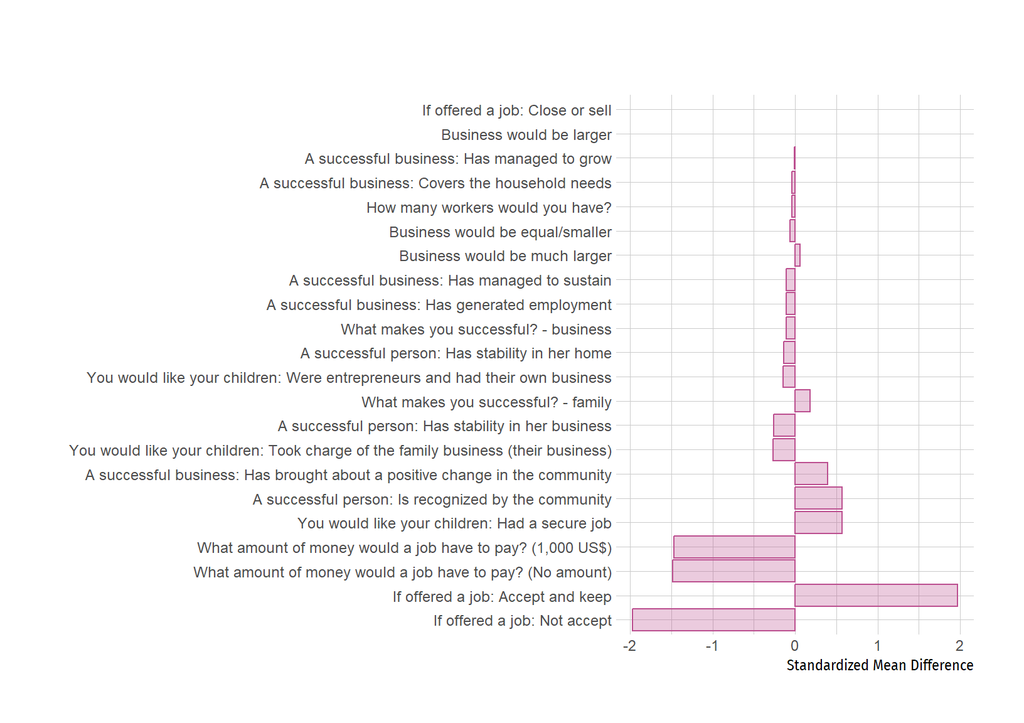

Figure 1. Variable Importance in Cluster Formation

# Characteristics by cluster

In this section, we compare different characteristics by clusters, as previously defined. We can see that clients in Cluster 2 have better loan characteristics and business performance, but they have otherwise similar characteristics in terms of risk and loss aversion and investment decisions. Surprisingly, individuals in Cluster 2 have lower education compared to Cluster 1, and are more likely to be the main providers for their households.

Table 2. Balance table across clients’ characteristics according to clusters - Loan characteristics and Business Performance

|  | Cluster 1 (N=1188) / Mean | Cluster 2 (N=461) / Mean | Diff. in Means |
| --- | --- | --- | --- |
| 1st loan amount | -0.027 | 0.189 | 0.216 |
| Surplus on 1st loan (SD) | -0.014 | 0.172 | 0.186 |
| Surplus on last loan (SD) | 0.007 | 0.174 | 0.167 |
| Expected number of workers | 6.843 | 8.197 | 1.354 |
| Regarding the first year of activity of your business, the annual sales of your business are - They are much higher | 0.228 | 0.315 | 0.086 |
| Regarding the first year of activity of your business, the annual sales of your business are - They are higher, but not by much. | 0.439 | 0.430 | -0.009 |
| Regarding the first year of activity of your business, the annual sales of your business are - They are the same. | 0.115 | 0.080 | -0.035 |
| Regarding the first year of activity of your business, the annual sales of your business are - They are lower. | 0.169 | 0.143 | -0.026 |
| Regarding the first year of activity of your business, the annual sales of your business are - I’ve had my business for less than a year | 0.012 | 0.007 | -0.005 |

Note:  
Cells highlighted according to whether they are statistically different at conventional levels

Table 3. Balance table across clients’ characteristics according to clusters - Investment decisions

|  | Cluster 1 (N=1188) / Mean | Cluster 2 (N=461) / Mean | Diff. in Means |
| --- | --- | --- | --- |
| If you received $4,000, you would use that money for growing your business | 0.812 | 0.826 | 0.014 |
| When you have gains from your business, you usually invest in growing your business | 0.532 | 0.562 | 0.030 |

Note:  
Cells highlighted according to whether they are statistically different at conventional levels

Table 4. Balance table across clients’ characteristics according to clusters - Attitudes

|  | Cluster 1 (N=1188) / Mean | Cluster 2 (N=461) / Mean | Diff. in Means |
| --- | --- | --- | --- |
| Loss aversion (-) | 3.074 | 3.239 | 0.165 |
| Risk aversion (-) | 2.253 | 2.174 | -0.079 |
| Dishonesty (proxy) | 1.253 | 1.215 | -0.039 |
| If you get presented with an opportunity, you think of: In the potential to increase their income. | 0.648 | 0.677 | 0.029 |
| If you get presented with an opportunity, you think of: In the possible risks. | 0.109 | 0.100 | -0.010 |
| With which phrase do you identify the most? Nothing ventured, nothing gained | 0.497 | 0.464 | -0.032 |
| With which phrase do you identify the most? A bird in the hand is worth two in the bush | 0.112 | 0.167 | 0.055 |

Note:  
Cells highlighted according to whether they are statistically different at conventional levels

Table 5. Balance table across clients’ characteristics according to clusters - Demographic characteristics

|  | Cluster 1 (N=1188) / Mean | Cluster 2 (N=461) / Mean | Diff. in Means |
| --- | --- | --- | --- |
| Gender - Female | 0.572 | 0.570 | -0.001 |
| Secondary education or more - Yes | 0.529 | 0.449 | -0.080 |
| Household income - Contribute more than 50% | 0.488 | 0.549 | 0.061 |
| Uses WhatsApp Yes | 0.852 | 0.866 | 0.014 |
| Age | 45.960 | 48.707 | 2.748 |
| Colombia | 0.229 | 0.299 | 0.070 |
| Dominican Republic | 0.234 | 0.302 | 0.068 |
| Panama | 0.217 | 0.165 | -0.052 |
| Peru | 0.320 | 0.234 | -0.086 |

Note:  
Cells highlighted according to whether they are statistically different at conventional levels

# Balancing Business Performance

We are also interested in analyzing whether the definitions of success for each individual are mainly mediated by the performance of their own business. For that reason, we match observations in Cluster 2 to Cluster 1 to balance the means of business’ performance with a tolerance of 0.025 SD. We are able to match 100% of the observations in Cluster 2, obtaining the following pre- and post-matching differences:

Table 7. Balance of business performance before and after matching

|  | Pre-matching Mean Cluster 2 | Pre-matching Mean Cluster 1 | Pre-matching Diff (SD) | Post-matching Mean Cluster 2 | Post-matching Mean Cluster 1 | Post-matching Diff (SD) |
| --- | --- | --- | --- | --- | --- | --- |
| Surplus - first loan | 0.172 | -0.014 | 0.187*** | 0.172 | 0.15 | 0.02 |
| Surplus - first loan (missing) | 0.022 | 0.031 | -0.059 | 0.022 | 0.024 | -0.015 |
| Surplus - last loan | 0.174 | 0.007 | 0.164*** | 0.174 | 0.153 | 0.02 |
| Surplus - last loan (missing) | 0.069 | 0.063 | 0.025 | 0.069 | 0.065 | 0.017 |
| Amount - first loan | 0.189 | -0.027 | 0.194*** | 0.189 | 0.166 | 0.019 |
| Amount - first loan (missing) | 0.004 | 0.011 | -0.076 | 0.004 | 0.004 | 0 |
| Amount - last loan | 0.194 | 0.005 | 0.176*** | 0.194 | 0.177 | 0.015 |
| Amount - last loan (missing) | 0.004 | 0.011 | -0.076 | 0.004 | 0.004 | 0 |
| Assets - first loan | 0.062 | -0.021 | 0.089 | 0.062 | 0.059 | 0.003 |
| Assets - first loan (missing) | 0.208 | 0.275 | -0.157*** | 0.208 | 0.219 | -0.026 |
| Assets - last loan | 0.128 | -0.031 | 0.156*** | 0.128 | 0.109 | 0.018 |
| Assets - last loan (missing) | 0.035 | 0.061 | -0.125** | 0.035 | 0.03 | 0.024 |

Analyzing now the differences between the matched observations, we can see that there are still significant differences between Cluster 1 and Cluster 2 in terms of their perspectives on success, even after adjusting by business performance:

Table 6. Balance table across clients’ responses according to clusters - After matching

|  | Cluster 1 (N=461) Mean | Cluster 1 (N=461) Std. Dev. | Cluster 2 (N=461) Mean | Cluster 2 (N=461) Std. Dev. | Diff. in Means | p |
| --- | --- | --- | --- | --- | --- | --- |
| What makes you successful? - business | 0.119 | 0.325 | 0.158 | 0.365 | 0.039 | 0.087 |
| What makes you successful? - family | 0.020 | 0.139 | 0.000 | 0.000 | -0.020 | 0.003 |
| A successful person: Is recognized by the community | 0.200 | 0.400 | 0.007 | 0.080 | -0.193 | 0.000 |
| A successful person: Has stability in her home | 0.395 | 0.489 | 0.449 | 0.498 | 0.054 | 0.096 |
| A successful person: Has stability in her business | 0.406 | 0.492 | 0.544 | 0.499 | 0.139 | 0.000 |
| A successful business: Has managed to grow | 0.349 | 0.477 | 0.360 | 0.481 | 0.011 | 0.731 |
| A successful business: Has managed to sustain | 0.228 | 0.420 | 0.260 | 0.439 | 0.033 | 0.251 |
| A successful business: Has generated employment | 0.132 | 0.339 | 0.174 | 0.379 | 0.041 | 0.082 |
| A successful business: Has brought about a positive change in the community | 0.119 | 0.325 | 0.000 | 0.000 | -0.119 | 0.000 |
| A successful business: Covers the household needs | 0.171 | 0.377 | 0.206 | 0.405 | 0.035 | 0.178 |
| Business would be much larger | 0.620 | 0.486 | 0.577 | 0.495 | -0.043 | 0.179 |
| Business would be equal/smaller | 0.380 | 0.486 | 0.423 | 0.495 | 0.043 | 0.179 |
| How many workers would you have? (prop. over current workers) | 3.445 | 3.644 | 3.579 | 4.152 | 0.134 | 0.603 |
| If offered a job: Accept and keep | 0.790 | 0.408 | 0.061 | 0.239 | -0.729 | 0.000 |
| If offered a job: Not accept | 0.210 | 0.408 | 0.939 | 0.239 | 0.729 | 0.000 |
| What amount of money would a job have to pay? (1,000 US$) | 5.388 | 5.480 | 11.976 | 0.535 | 6.588 | 0.000 |
| What amount of money would a job have to pay? (No amount) | 0.403 | 0.491 | 0.998 | 0.047 | 0.594 | 0.000 |
| You would like your children: Were entrepreneurs and had their own business | 0.577 | 0.495 | 0.644 | 0.479 | 0.067 | 0.036 |
| You would like your children: Took charge of the family business (their business) | 0.241 | 0.428 | 0.356 | 0.479 | 0.115 | 0.000 |
| You would like your children: Had a secure job | 0.182 | 0.386 | 0.000 | 0.000 | -0.182 | 0.000 |

Table 8. Balance table between Cluster 1 before and after matching

|  | Original (N=1188) Mean | Original (N=1188) Std. Dev. | Matched (N=461) Mean | Matched (N=461) Std. Dev. | Diff. in Means | p |
| --- | --- | --- | --- | --- | --- | --- |
| What makes you successful? - business | 0.121 | 0.327 | 0.119 | 0.325 | -0.002 | 0.915 |
| What makes you successful? - family | 0.024 | 0.152 | 0.020 | 0.139 | -0.004 | 0.605 |
| A successful person: Is recognized by the community | 0.200 | 0.400 | 0.200 | 0.400 | -0.001 | 0.972 |
| A successful person: Has stability in her home | 0.383 | 0.486 | 0.395 | 0.489 | 0.012 | 0.660 |
| A successful person: Has stability in her business | 0.417 | 0.493 | 0.406 | 0.492 | -0.011 | 0.683 |
| A successful business: Has managed to grow | 0.355 | 0.479 | 0.349 | 0.477 | -0.006 | 0.820 |
| A successful business: Has managed to sustain | 0.216 | 0.412 | 0.228 | 0.420 | 0.011 | 0.618 |
| A successful business: Has generated employment | 0.136 | 0.343 | 0.132 | 0.339 | -0.004 | 0.829 |
| A successful business: Has brought about a positive change in the community | 0.102 | 0.303 | 0.119 | 0.325 | 0.017 | 0.318 |
| A successful business: Covers the household needs | 0.190 | 0.393 | 0.171 | 0.377 | -0.019 | 0.368 |
| Business would be much larger | 0.608 | 0.488 | 0.620 | 0.486 | 0.013 | 0.636 |
| Business would be equal/smaller | 0.392 | 0.488 | 0.380 | 0.486 | -0.013 | 0.636 |
| How many workers would you have? (prop. over current workers) | 3.421 | 3.515 | 3.445 | 3.644 | 0.023 | 0.906 |
| If offered a job: Accept and keep | 0.788 | 0.409 | 0.790 | 0.408 | 0.002 | 0.939 |
| If offered a job: Not accept | 0.212 | 0.409 | 0.210 | 0.408 | -0.002 | 0.939 |
| What amount of money would a job have to pay? (1,000 US$) | 5.187 | 5.439 | 5.388 | 5.480 | 0.201 | 0.503 |
| What amount of money would a job have to pay? (No amount) | 0.385 | 0.487 | 0.403 | 0.491 | 0.019 | 0.485 |
| You would like your children: Were entrepreneurs and had their own business | 0.573 | 0.495 | 0.577 | 0.495 | 0.004 | 0.889 |
| You would like your children: Took charge of the family business (their business) | 0.238 | 0.426 | 0.241 | 0.428 | 0.003 | 0.913 |
| You would like your children: Had a secure job | 0.189 | 0.391 | 0.182 | 0.386 | -0.006 | 0.766 |

Analyzing potential differences in other outcomes, we obtain the following results after matching:

Table 9. Difference in characteristics between Cluster 1 and Cluster 2 - After Matching

|  | Cluster 1 (N=461) Mean | Cluster 1 (N=461) Std. Dev. | Cluster 2 (N=461) Mean | Cluster 2 (N=461) Std. Dev. | Diff. in Means | p |
| --- | --- | --- | --- | --- | --- | --- |
| If you received $4,000, you would use that money for growing your business | 0.798 | 0.402 | 0.826 | 0.379 | 0.028 | 0.273 |
| When you have gains from your business, you usually invest in growing your business | 0.518 | 0.500 | 0.562 | 0.497 | 0.043 | 0.187 |
| What size would your business be in 5 years? - Much larger/larger | 0.620 | 0.486 | 0.577 | 0.495 | -0.043 | 0.179 |
| Expected number of workers | 6.833 | 7.911 | 8.197 | 16.473 | 1.364 | 0.109 |
| Loss aversion (-) | 3.102 | 2.105 | 3.239 | 2.123 | 0.137 | 0.327 |
| Risk aversion (-) | 2.215 | 1.881 | 2.174 | 1.985 | -0.041 | 0.746 |
| Dishonesty (proxy) | 1.154 | 1.078 | 1.215 | 1.065 | 0.061 | 0.390 |
| If you get presented with an opportunity, you think of: In the potential to increase their income. | 0.625 | 0.485 | 0.677 | 0.468 | 0.052 | 0.098 |
| If you get presented with an opportunity, you think of: In the possible risks. | 0.121 | 0.327 | 0.100 | 0.300 | -0.022 | 0.294 |
| With which phrase do you identify the most? Nothing ventured, nothing gained | 0.453 | 0.498 | 0.464 | 0.499 | 0.011 | 0.741 |
| With which phrase do you identify the most? A bird in the hand is worth two in the bush | 0.121 | 0.327 | 0.167 | 0.373 | 0.046 | 0.049 |
| Regarding the first year of activity of your business, the annual sales of your business are - They are much higher | 0.247 | 0.432 | 0.315 | 0.465 | 0.067 | 0.023 |
| Regarding the first year of activity of your business, the annual sales of your business are - They are higher, but not by much. | 0.432 | 0.496 | 0.430 | 0.496 | -0.002 | 0.947 |
| Regarding the first year of activity of your business, the annual sales of your business are - They are the same. | 0.089 | 0.285 | 0.080 | 0.272 | -0.009 | 0.636 |
| Regarding the first year of activity of your business, the annual sales of your business are - They are lower. | 0.182 | 0.386 | 0.143 | 0.351 | -0.039 | 0.108 |
| Regarding the first year of activity of your business, the annual sales of your business are - I’ve had my business for less than a year | 0.004 | 0.066 | 0.007 | 0.080 | 0.002 | 0.654 |
| Household income - Contribute more than 50% | 0.497 | 0.501 | 0.549 | 0.498 | 0.052 | 0.114 |
| Gender - Female | 0.570 | 0.496 | 0.570 | 0.496 | 0.000 | 1.000 |
| Uses WhatsApp Yes | 0.861 | 0.346 | 0.866 | 0.342 | 0.004 | 0.848 |
| Secondary education or more - Yes | 0.505 | 0.501 | 0.449 | 0.498 | -0.056 | 0.087 |

# Prediction of Success

We are interested in using the information available to see which characteristics would be good predictors of success, especially depending on the definition of success the individual has. For this, we will use two different definitions of success: (i) Loan growth and timely payments, and (ii) Success score.

The first measure, which was used for stratification purposes for sampling our survey population, identifies clients who have had growth in terms of loan amount (between their first and last registered loan), as well as overall timely payments. The second measure identifies micro-entrepreneurs that belong to the top quartile of a success score built on their (standardized) growth in terms of assets and loan amount.

## Measure 1: Loan growth and timely payments

For predicting the success for the entire sample (only including individuals that currently have a business and that had more than one loan), we use `xgboost` as the prediction model. We find that accuracy is low, with an average accuracy rate of 56.5%.

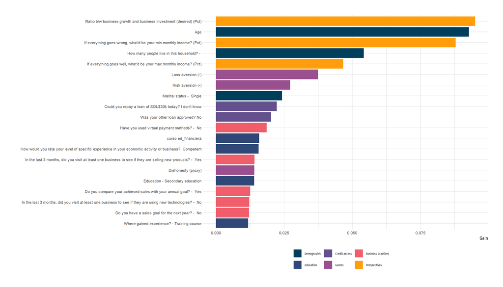

Figure 2. Variable importance for success variable prediction - Entire sample

When we look at the different groups by their definition of success, we get an accuracy rate of 51.7% for Cluster 1.

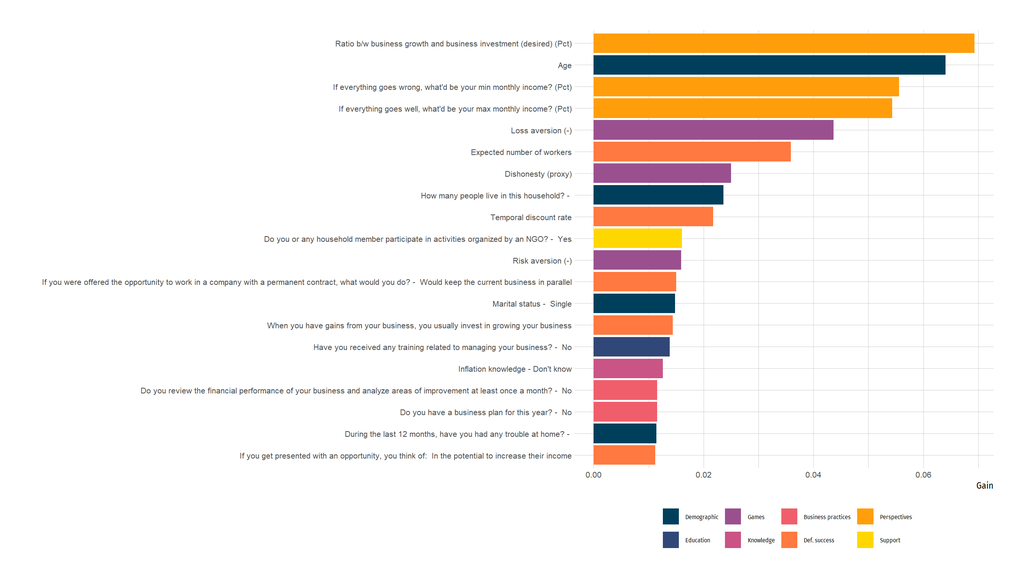

Figure 3. Variable importance for success variable prediction - Community/family oriented group (Cluster 1)

When we look at the different groups by their definition of success, we get an accuracy rate of 50.6% for Cluster 2.

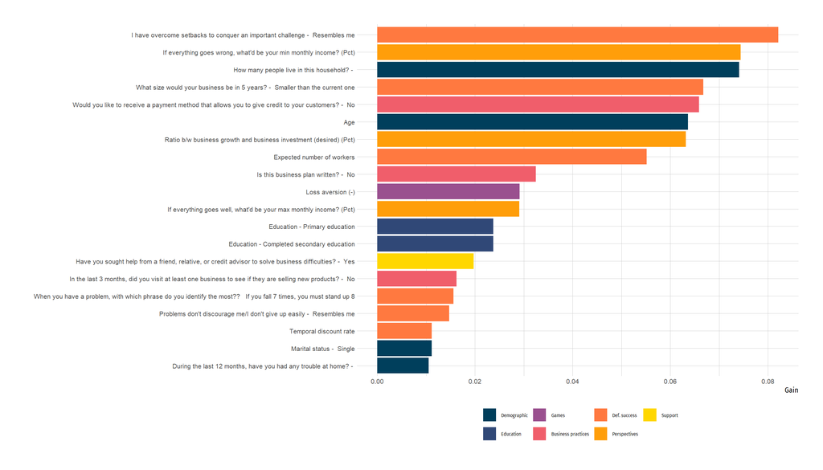

Figure 4. Variable importance for success variable prediction - Business oriented group (Cluster 2)

## Measure 2: Success score

We define success score as:

$$Score \ Success_i = \frac{1}{3}(\Delta
Loan Amount_i + \Delta Assets_i + \Delta Surplus_i)$$

where $\Delta X$ represents the change between the last available loan and the first one. All variables are standardized, so they are comparable. If an individual is missing one of these variables, then the weight is re-distributed between the available data. In this case, we are predicting the probability of being in the top 25% of this score. In terms of our previous definitions of success, individuals that have a business-oriented definition of success are more likely to be in the top 25% (30.7%) compared to the community/family-oriented cluster (23%).

Using the same `xgboost` method as for the previous measure, we have an accuracy in prediction of 73.9% for the entire sample.

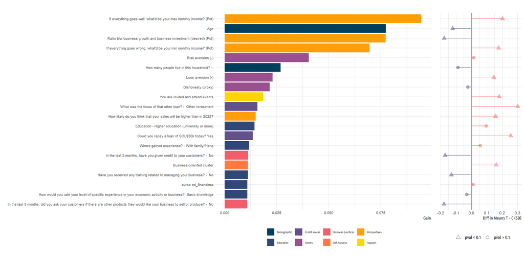

Figure 5. Variable importance for Top 25% of Success Score prediction - Entire sample

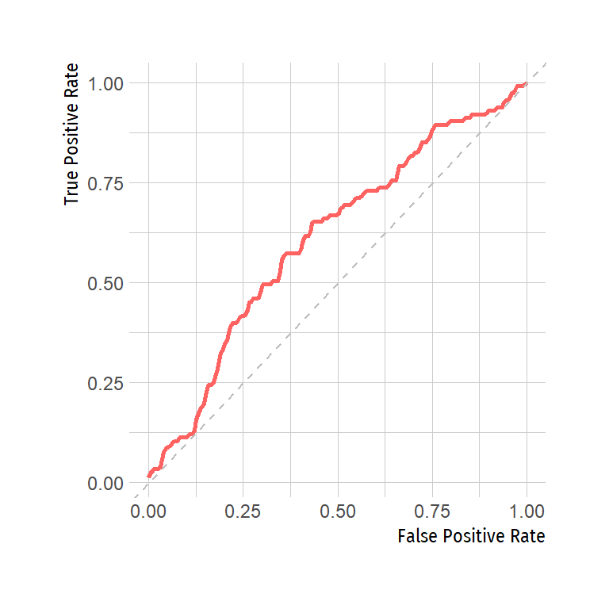

Figure 6. ROC - Entire Sample

We can also analyze the partial change in probabilities for some of the predictors that are deemed some of the most important in the data:

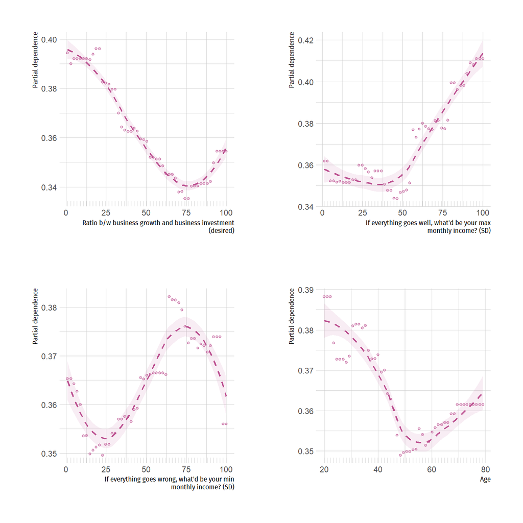

Figure 7. Partial dependence between Top 25% Success and top predictors of full model

For the group that has a community/family vision of success, we have an accuracy in prediction of 76.7%.

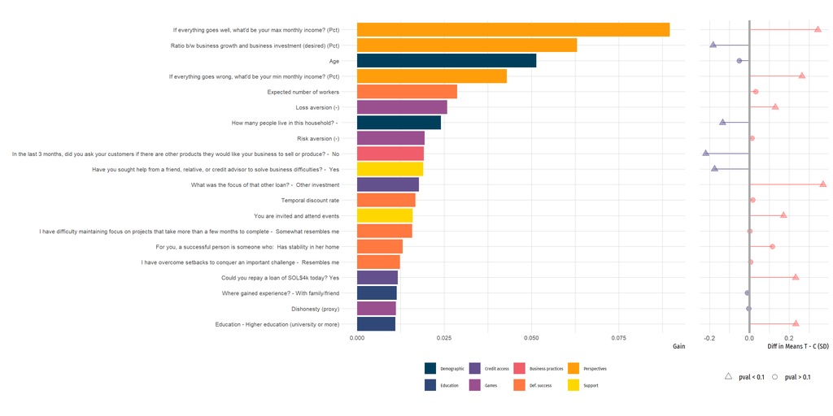

Figure 8. Variable importance for Top 25% of Success Score prediction - Community/Family oriented group (Cluster 1)

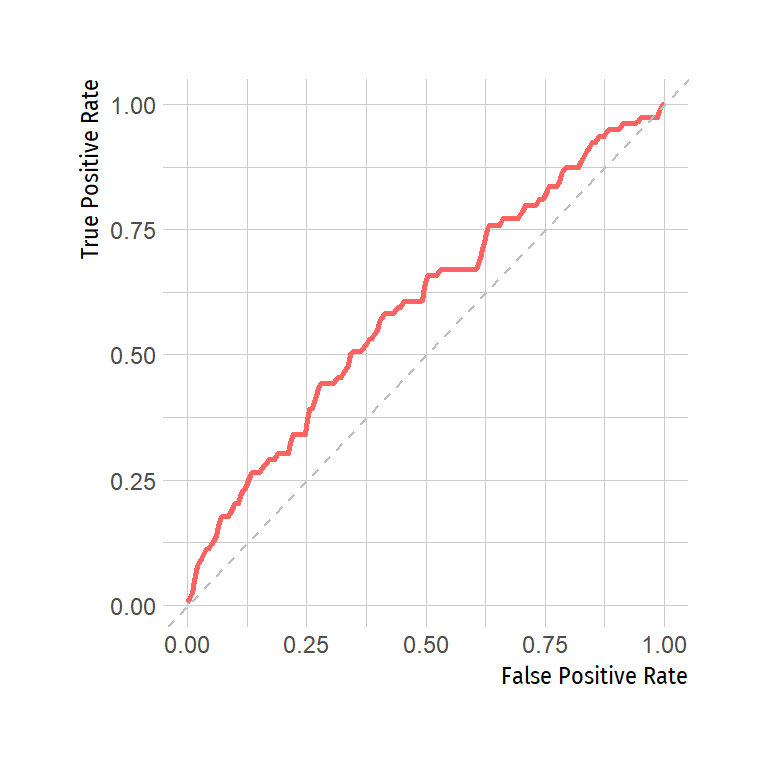

Figure 9. ROC - Community/Family oriented group (Cluster 1)

For the group that has a business-like definition of success, we have an accuracy in prediction of 65.6%.

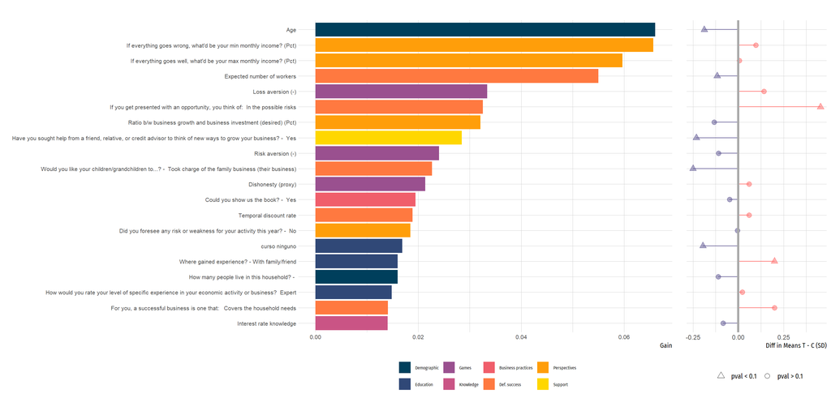

Figure 10. Variable importance for Top 25% of Success Score prediction - Business oriented group (Cluster 2)

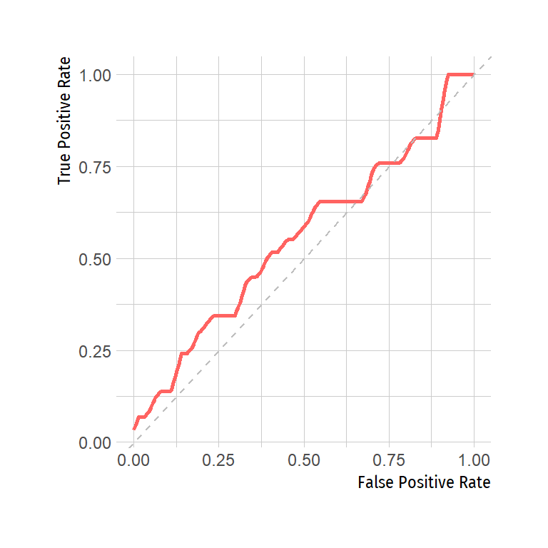

Figure 11. ROC - Business oriented group (Cluster 2)

# Variable selection

We would like to select the most predictive covariates in our survey (up to 15 features) to reeduce the dimensionality of the instrument. For this, we use Recursive Feature Elimination in combination with Random Forest to select models with 5, 7, 10, and 15 features. In this case, the selected model has 7 variables, with an accuracy of 73.6% in the testing data. The selected features are the following:

Table 10. Selected variables through Recursive Feature Elimination

| Variables |
| --- |
| If everything goes well, what’d be your max monthly income? (Pct) |
| What was the focus of that other loan? - Other investment |
| Ratio b/w business growth and business investment (desired) (Pct) |
| You are invited and attend events |
| If everything goes wrong, what’d be your min monthly income? (Pct) |
| Where gained experience? - With family/friend |
| Loss aversion (-) |

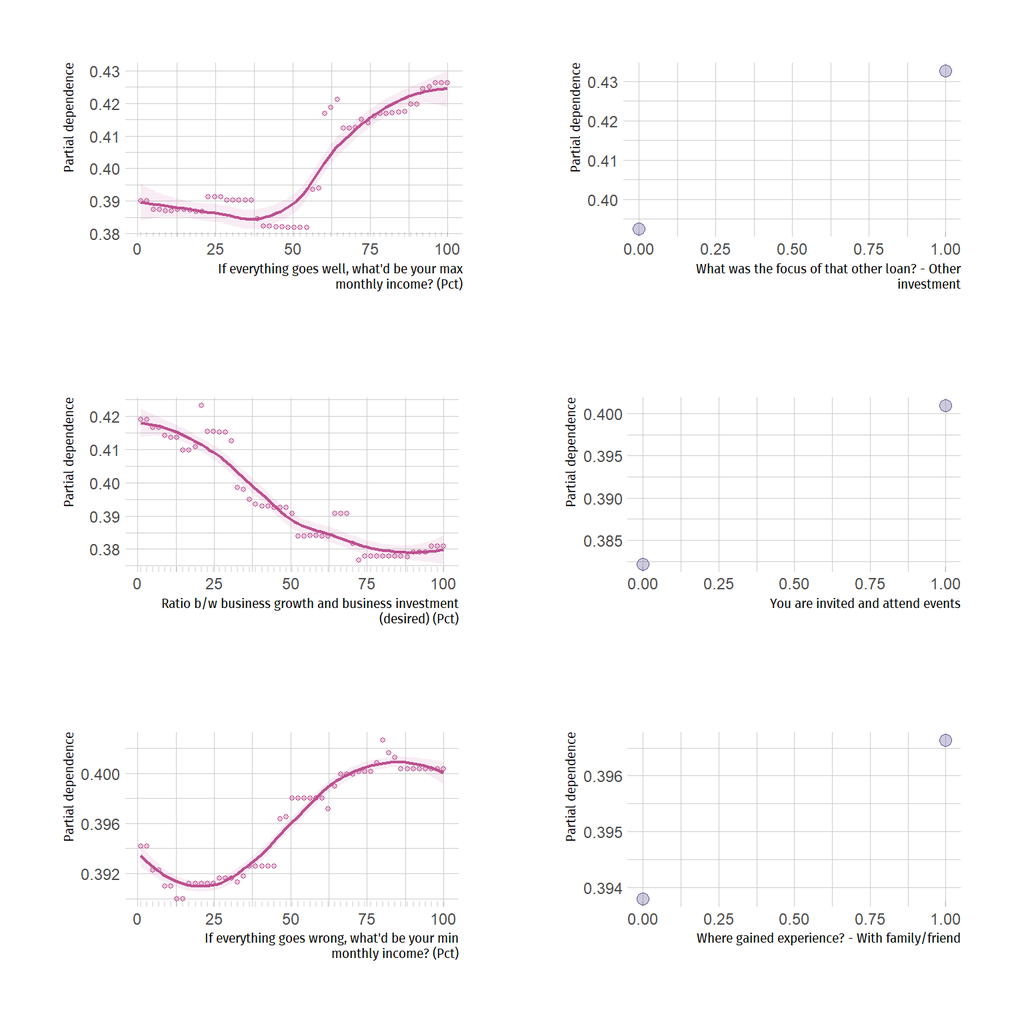

Figure 12. Partial dependence between Top 25% Success Score and most relevant predictors

[^1]: University of Texas at Austin, m.bennett@austin.utexas.edu
[^2]: University of Texas at Austin, william.fuchs@mccombs.utexas.edu
[^3]: Universidad de Navarra, jmillan@…